# EDA 5 — LOP Component Decomposition: Sections 4.1 and 4.2

Dissecting the Primary Outcome Variable into Its 8 Reason Categories

Author

Analysis Team

Published

May 22, 2026

# Mission

This EDA opens the “black box” of `days_absent_total` by examining the 8 individual LOP reason categories from which it is constructed. It directly addresses:

- **Section 4.1** — Outcome variable construction: prevalence of each reason, relative contribution to the overall burden, co-occurrence patterns across reason pairs, and a data-quality validation confirming that zeros are preserved (not stored as `NA`) after the element-wise exclusion step.
- **Section 4.2** — Distributional statistics for the primary outcome: zero inflation fraction, frequency distribution shape, conditional intensity among reporters, and the structural role of the chronic-condition component.

**Research Questions:**

1. What is the weighted prevalence of each of the 8 LOP reason categories?
2. How much does each LOP component contribute to the weighted mean of `days_absent_total`?
3. How many reason categories does a typical respondent report simultaneously, and which pairs most frequently co-occur?
4. Among reporters of a given reason, how many days does that reason typically produce?
5. What structural role does the chronic-condition component play among absent workers?
6. Are all 8 LOP components complete in the analytical sample, validating the element-wise exclusion step that removed 405 respondents upstream?

> **Bootstrap weights note**: Confidence intervals via bootstrap are not available for CCHS 2010 and 2014 PUMF cycles. Variance estimates rely on the pooled master weight (`wts_m_pooled`) only. This is a known limitation documented in the CACHE manifest and confirmed in the 2026-05-15 review session with Marc-André Blanchette.

Following the dual-file development pattern, all analytical code lives in `analysis/eda-5/eda-5.R`. This document sources those chunks for presentation.

# Definition of Terms

**LOP module**: Loss of Productivity module from the CCHS. Respondents are asked how many workdays they missed in the past 3 months due to each of 8 distinct health-related reasons.

**`days_absent_total`**: The primary outcome. Row-wise sum of all 8 LOP component variables (`lopg040` + `lopg070` + `lopg082`–`lopg086` + `lopg100`), capped at 90 days.

**`days_absent_chronic`**: The sensitivity outcome. Days missed due to chronic condition only (`lopg040`), capped at 90 days.

**Element-wise exclusion**: 405 respondents with any missing value across the 8 LOP components were excluded at Ellis pipeline step 4 (see CACHE manifest). In the analytical sample the zero response is preserved as a valid integer value, not stored as `NA`.

**LOP reason categories (8 components):**

| Variable | Reason |
| --- | --- |
| `lopg040` | Own chronic condition |
| `lopg070` | Injury |
| `lopg082` | Cold |
| `lopg083` | Flu / influenza |
| `lopg084` | Gastroenteritis (stomach flu) |
| `lopg085` | Respiratory infection |
| `lopg086` | Other infectious disease |
| `lopg100` | Other physical / mental health reason |

# Environment

**Packages used in this report**

```r
library(magrittr)
library(ggplot2)
library(forcats)
library(stringr)
library(dplyr)
library(tidyr)
library(scales)
library(fs)
requireNamespace("arrow")
```

**Project-level utilities**

```r
base::source("./scripts/common-functions.R")
base::source("./scripts/operational-functions.R")
if (file.exists("./scripts/graphing/graph-presets.R")) {
  base::source("./scripts/graphing/graph-presets.R")
}
```

**Paths, LOP component map, constants**

```r
local_root    <- "./analysis/eda-5/"
local_data    <- paste0(local_root, "data-local/")
prints_folder <- paste0(local_root, "prints/")
data_private_derived <- "./data-private/derived/eda-5/"

if (!fs::dir_exists(local_data))           fs::dir_create(local_data)
if (!fs::dir_exists(prints_folder))        fs::dir_create(prints_folder)
if (!fs::dir_exists(data_private_derived)) fs::dir_create(data_private_derived)

path_cchs2_parquet  <- "./data-private/derived/cchs-2-tables"
path_analytical_pq  <- file.path(path_cchs2_parquet, "cchs_analytic.parquet")
weight_col          <- "wts_m_pooled"

# LOP component columns and their human-readable labels
lop_components <- c(
  "lopg040" = "Chronic condition",
  "lopg070" = "Injury",
  "lopg082" = "Cold",
  "lopg083" = "Flu / influenza",
  "lopg084" = "Gastroenteritis",
  "lopg085" = "Respiratory infection",
  "lopg086" = "Other infectious disease",
  "lopg100" = "Other physical / mental health"
)
```

**Load cchs_analytic.parquet (n = 63,843)**

```r
if (!file.exists(path_analytical_pq)) {
  stop("Missing required file: ", path_analytical_pq, call. = FALSE)
}

ds0 <- arrow::read_parquet(path_analytical_pq)

required_cols <- c(
  weight_col, "days_absent_total", "days_absent_chronic",
  "cchs_cycle", "cchs_cycle_f",
  names(lop_components)
)
missing_required <- setdiff(required_cols, names(ds0))
if (length(missing_required) > 0) {
  stop("Missing required columns in cchs_analytic.parquet: ",
       paste(missing_required, collapse = ", "), call. = FALSE)
}

cat(sprintf("Loaded analytical data: %s rows, %s columns\n",
            format(nrow(ds0), big.mark = ","),
            format(ncol(ds0), big.mark = ",")))
```

```
Loaded analytical data: 63,843 rows, 69 columns
```

# Data Context

For complete data documentation, see the Data Primer.

**Source table and file location**

```r
data_context_tables <- tibble::tibble(
  source_table = "cchs_analytic.parquet",
  location     = path_analytical_pq,
  rows         = nrow(ds0),
  columns      = ncol(ds0),
  usage        = paste(
    "All 8 raw LOP component columns + derived days_absent_total,",
    "days_absent_chronic, and pooled survey weight wts_m_pooled"
  )
)
print(data_context_tables)
```

```
# A tibble: 1 × 5
  source_table          location                                                  rows columns usage
  <chr>                 <chr>                                                    <int>   <int> <chr>
1 cchs_analytic.parquet ./data-private/derived/cchs-2-tables/cchs_analytic.parq… 63843      69 All …
```

**Representative individuals — LOP components and derived outcomes visible**

```r
# A respondent with activity on at least 3 LOP components — shows the key columns
data_context_person <- ds0 %>%
  select(
    cchs_cycle_f, !!weight_col,
    days_absent_total, days_absent_chronic,
    all_of(names(lop_components))
  ) %>%
  filter(
    rowSums(
      select(., all_of(names(lop_components))) > 0,
      na.rm = TRUE
    ) >= 3
  ) %>%
  slice_head(n = 2)
print(data_context_person)
```

```
# A tibble: 2 × 12
  cchs_cycle_f wts_m_pooled days_absent_total days_absent_chronic lopg040 lopg070 lopg082 lopg083
  <fct>               <dbl>             <dbl>               <dbl>   <dbl>   <dbl>   <dbl>   <dbl>
1 2010-2011            285.                 8                   0       0       0       3       0
2 2010-2011            865.                 7                   1       1       0       3       0
# ℹ 4 more variables: lopg084 <dbl>, lopg085 <dbl>, lopg086 <dbl>, lopg100 <dbl>
```

**Non-missing counts and raw prevalence per component**

```r
# Non-missing counts, zero counts, and raw prevalence per LOP component
data_context_distributions <- ds0 %>%
  summarise(
    across(
      all_of(names(lop_components)),
      list(
        n_nonmissing = ~ sum(!is.na(.x)),
        n_zero       = ~ sum(.x == 0,  na.rm = TRUE),
        n_positive   = ~ sum(.x > 0,   na.rm = TRUE),
        pct_positive = ~ mean(.x > 0,  na.rm = TRUE) * 100
      )
    )
  ) %>%
  tidyr::pivot_longer(
    cols         = everything(),
    names_to     = c("column", ".value"),
    names_pattern = "^(.+)_(n_nonmissing|n_zero|n_positive|pct_positive)$"
  ) %>%
  mutate(reason_label = lop_components[column])
print(data_context_distributions)
```

```
# A tibble: 8 × 6
  column  n_nonmissing n_zero n_positive pct_positive reason_label
  <chr>          <int>  <int>      <int>        <dbl> <chr>
1 lopg040        63843  60217       3626        5.68  Chronic condition
2 lopg070        63843  61624       2219        3.48  Injury
3 lopg082        63843  58512       5331        8.35  Cold
4 lopg083        63843  61381       2462        3.86  Flu / influenza
5 lopg084        63843  61737       2106        3.30  Gastroenteritis
6 lopg085        63843  63213        630        0.987 Respiratory infection
7 lopg086        63843  63140        703        1.10  Other infectious disease
8 lopg100        63843  58464       5379        8.43  Other physical / mental health
```

**Reshape to long-form LOP dataset (shared ancestor for G1–G6)**

```r
# Long-form LOP component dataset — shared ancestor for G1, G2, G3, G4, G6 families

ds_lop_long <- ds0 %>%
  select(
    cchs_cycle, cchs_cycle_f, !!weight_col,
    days_absent_total, days_absent_chronic,
    all_of(names(lop_components))
  ) %>%
  tidyr::pivot_longer(
    cols      = all_of(names(lop_components)),
    names_to  = "lop_col",
    values_to = "days_reason"
  ) %>%
  mutate(
    reason_label = lop_components[lop_col],
    reason_label = factor(reason_label, levels = lop_components),
    has_days     = !is.na(days_reason) & days_reason > 0
  )


# =============================================================================
# G0 FAMILY — Outcome Distribution Orientation
# Framing question: How does absence distribute across the analytical sample?
# g0  : zero vs non-zero split (horizontal stacked bar)
# g01 : histogram of total missed days among the ≥1-day group, coloured by day range
# g02 : day-range breakdown stacked bar for the ≥1-day group
# =============================================================================
```

# Analysis

## G0 — Outcome Distribution Orientation

**Framing question**: How does absence distribute across the analytical sample — and among those who missed at least one day, what does the day-count distribution look like?

**Zero / non-zero group counts and weighted shares**

```r
g0_data <- ds0 %>%
  mutate(
    absent_group = dplyr::if_else(
      !is.na(days_absent_total) & days_absent_total >= 1,
      "At least one missed day",
      "No missed days (zero)"
    ),
    absent_group = factor(
      absent_group,
      levels = c("No missed days (zero)", "At least one missed day")
    )
  ) %>%
  group_by(absent_group) %>%
  summarise(
    n_people  = n(),
    wt_people = sum(.data[[weight_col]], na.rm = TRUE),
    .groups   = "drop"
  ) %>%
  mutate(
    pct_n  = n_people  / sum(n_people)  * 100,
    pct_wt = wt_people / sum(wt_people) * 100
  )
```

**G0 — Horizontal stacked bar, zero vs ≥1 absent day**

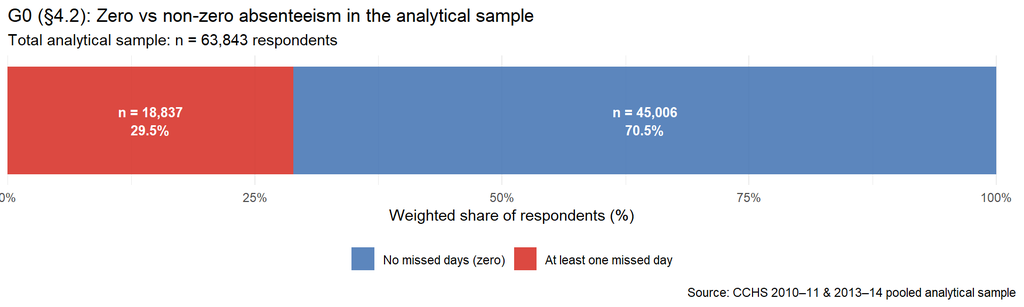

G0: The analytical sample splits approximately 70/30 between workers with no missed days and those with ≥1 missed day — consistent with the zero-inflated structure described in Kermiche et al. (2025) and confirmed in the 2026-05-15 review session.

```r
# Horizontal stacked bar: zero vs ≥1 absent day, unweighted n and weighted %

g0_labels <- g0_data %>%
  mutate(
    bar_label = sprintf("%s\nn = %s  (%.1f%%)",
                        absent_group,
                        scales::comma(n_people),
                        pct_n)
  )

g0_lop_zero_vs_nonzero <- g0_data %>%
  ggplot(aes(x = pct_wt, y = "Analytical sample", fill = absent_group)) +
  geom_col(width = 1.0, alpha = 0.88) +
  geom_text(
    data      = g0_labels,
    aes(
      x     = pct_wt,
      label = sprintf("n = %s\n%.1f%%", scales::comma(n_people), pct_n)
    ),
    position   = position_stack(vjust = 0.5),
    size       = 3.4,
    colour     = "white",
    fontface   = "bold",
    lineheight = 1.1
  ) +
  scale_x_continuous(
    labels = label_percent(scale = 1),
    expand = expansion(mult = c(0, 0.02))
  ) +
  scale_fill_manual(
    values = c(
      "No missed days (zero)"   = "#4575b4",
      "At least one missed day" = "#d73027"
    )
  ) +
  labs(
    title    = "G0 (\u00a74.2): Zero vs non-zero absenteeism in the analytical sample",
    subtitle = sprintf("Total analytical sample: n = %s respondents",
                       scales::comma(sum(g0_data$n_people))),
    x        = "Weighted share of respondents (%)",
    y        = NULL,
    fill     = NULL,
    caption  = "Source: CCHS 2010\u201311 & 2013\u201314 pooled analytical sample"
  ) +
  theme_minimal(base_size = 11) +
  theme(
    axis.text.y        = element_blank(),
    axis.ticks.y       = element_blank(),
    panel.grid.major.y = element_blank(),
    legend.position    = "bottom"
  )

ggsave(paste0(prints_folder, "g0_lop_zero_vs_nonzero.png"),
       g0_lop_zero_vs_nonzero, width = 10, height = 3, dpi = 300)
print(g0_lop_zero_vs_nonzero)
```

**Restrict to ≥1-day group; assign day-range colour palette**

```r
# Shared setup for g01 and g02: restrict to ≥1-day group; assign day-range category

day_range_levels  <- c("1 day", "2 days", "3 days", "4 days", "5 days",
                       "6\u201310 days", "11\u201315 days", "16\u201330 days", "31+ days")
day_range_colours <- c(
  "1 day"           = "#f7941d",
  "2 days"          = "#e8601c",
  "3 days"          = "#cc3311",
  "4 days"          = "#aa1133",
  "5 days"          = "#880044",
  "6\u201310 days"  = "#6a0177",
  "11\u201315 days" = "#49006a",
  "16\u201330 days" = "#2d004b",
  "31+ days"        = "#0d0014"
)

ds_nonzero <- ds0 %>%
  filter(!is.na(days_absent_total), days_absent_total >= 1) %>%
  mutate(
    day_range = dplyr::case_when(
      days_absent_total == 1  ~ "1 day",
      days_absent_total == 2  ~ "2 days",
      days_absent_total == 3  ~ "3 days",
      days_absent_total == 4  ~ "4 days",
      days_absent_total == 5  ~ "5 days",
      days_absent_total <= 10 ~ "6\u201310 days",
      days_absent_total <= 15 ~ "11\u201315 days",
      days_absent_total <= 30 ~ "16\u201330 days",
      TRUE                    ~ "31+ days"
    ),
    day_range = factor(day_range, levels = day_range_levels)
  )
```

**G01 — Histogram of total missed days, coloured by day-range band**

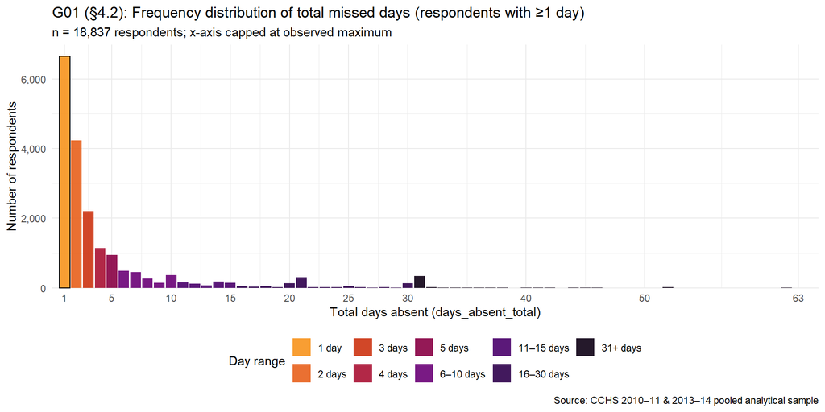

G01: Frequency histogram for respondents with ≥1 missed day. The heavy concentration at 1–5 days and a long right tail (up to 63 days) characterise the right-skewed count distribution. Bar colours link to the same day-range bands as G02.

```r
# Frequency histogram: x = total days missed, y = respondents
# Bars coloured by the same day-range palette used in g02

g01_hist_data <- ds_nonzero %>%
  count(days_absent_total, day_range)

g01_lop_days_histogram <- g01_hist_data %>%
  ggplot(aes(x = days_absent_total, y = n, fill = day_range)) +
  geom_col(width = 0.9, alpha = 0.90) +
  geom_col(
    data    = ~ filter(.x, days_absent_total == 1),
    width   = 0.9, colour = "black", fill = NA, alpha = 0.5
  ) +
  scale_x_continuous(
    breaks = c(1, 5, 10, 15, 20, 25, 30, 40, 50, 63),
    expand = expansion(mult = c(0.01, 0.02))
  ) +
  scale_y_continuous(
    labels = scales::label_comma(),
    expand = expansion(mult = c(0, 0.05))
  ) +
  scale_fill_manual(values = day_range_colours) +
  labs(
    title    = "G01 (\u00a74.2): Frequency distribution of total missed days (respondents with \u22651 day)",
    subtitle = sprintf("n = %s respondents; x-axis capped at observed maximum",
                       scales::comma(nrow(ds_nonzero))),
    x        = "Total days absent (days_absent_total)",
    y        = "Number of respondents",
    fill     = "Day range",
    caption  = "Source: CCHS 2010\u201311 & 2013\u201314 pooled analytical sample"
  ) +
  theme_minimal(base_size = 11) +
  theme(legend.position = "bottom")

ggsave(paste0(prints_folder, "g01_lop_days_histogram.png"),
       g01_lop_days_histogram, width = 10, height = 5, dpi = 300)
print(g01_lop_days_histogram)
```

**Summarise ≥1-day group by day-range category**

```r
g02_data <- ds_nonzero %>%
  group_by(day_range) %>%
  summarise(
    n_people  = n(),
    wt_people = sum(.data[[weight_col]], na.rm = TRUE),
    .groups   = "drop"
  ) %>%
  mutate(
    pct_n  = n_people  / sum(n_people)  * 100,
    pct_wt = wt_people / sum(wt_people) * 100
  )
```

**G02 — Horizontal stacked bar, day-range breakdown**

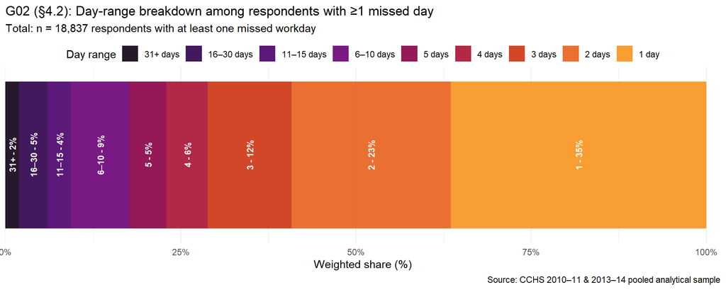

G02: Among workers who missed ≥1 day, the majority fall in the short-absence bands (1–5 days). The proportion with ≥6 days is smaller but non-trivial and driven substantially by chronic conditions.

```r
# Horizontal stacked bar: day-range breakdown for the ≥1-day group

g02_lop_day_ranges <- g02_data %>%
  ggplot(aes(x = pct_wt, y = "Respondents with \u22651 day", fill = day_range)) +
  geom_col(width = 1.0, alpha = 0.90) +
  geom_text(
    aes(label = sprintf("%s - %.0f%%",
                        stringr::str_remove(as.character(day_range), " days?$"),
                        pct_n)),
    position   = position_stack(vjust = 0.5),
    angle      = 90,
    size       = 3.0,
    colour     = "white",
    fontface   = "bold",
    lineheight = 1.1
  ) +
  scale_x_continuous(
    labels = scales::label_percent(scale = 1),
    expand = expansion(mult = c(0, 0.02))
  ) +
  scale_fill_manual(values = day_range_colours) +
  labs(
    title    = "G02 (\u00a74.2): Day-range breakdown among respondents with \u22651 missed day",
    subtitle = sprintf("Total: n = %s respondents with at least one missed workday",
                       scales::comma(nrow(ds_nonzero))),
    x        = "Weighted share (%)",
    y        = NULL,
    fill     = "Day range",
    caption  = "Source: CCHS 2010\u201311 & 2013\u201314 pooled analytical sample"
  ) +
  theme_minimal(base_size = 11) +
  theme(
    axis.text.y        = element_blank(),
    axis.ticks.y       = element_blank(),
    panel.grid.major.y = element_blank(),
    legend.position    = "top",
    legend.box.margin  = margin(0, 0, -12, 0)
  ) +
  guides(fill = guide_legend(nrow = 1, reverse = TRUE))

ggsave(paste0(prints_folder, "g02_lop_day_ranges.png"),
       g02_lop_day_ranges, width = 10, height = 4, dpi = 300)
print(g02_lop_day_ranges)
```

**G02 — Horizontal stacked bar, day-range breakdown**

```r
# =============================================================================
# G1 FAMILY — Prevalence of Each LOP Reason Category
# Framing question: What proportion of workers missed ≥1 workday for each reason?
# g1  : weighted prevalence, ordered horizontal bar
# g11 : prevalence by survey cycle (2010-2011 vs 2013-2014)
# =============================================================================
```

## G1 — Prevalence of Each LOP Reason Category

**Framing question**: What proportion of workers in the analytical sample missed ≥1 workday for each of the 8 reason categories?

**Weighted and unweighted prevalence per reason**

```r
g1_data <- ds_lop_long %>%
  group_by(reason_label) %>%
  summarise(
    n_total        = n(),
    n_positive     = sum(has_days, na.rm = TRUE),
    wt_positive    = sum(.data[[weight_col]][has_days], na.rm = TRUE),
    wt_total       = sum(.data[[weight_col]],           na.rm = TRUE),
    pct_weighted   = wt_positive / wt_total * 100,
    pct_unweighted = n_positive  / n_total  * 100,
    .groups = "drop"
  ) %>%
  arrange(desc(pct_weighted)) %>%
  mutate(reason_label = forcats::fct_reorder(reason_label, pct_weighted))
```

**G1 — Weighted prevalence horizontal bar, ordered descending**

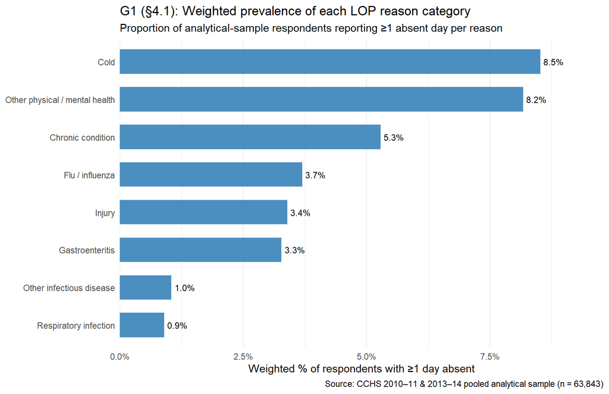

```r
g1_lop_prevalence <- g1_data %>%
  ggplot(aes(x = pct_weighted, y = reason_label)) +
  geom_col(fill = "#2c7bb6", alpha = 0.85, width = 0.65) +
  geom_text(
    aes(label = sprintf("%.1f%%", pct_weighted)),
    hjust = -0.15,
    size  = 3.2
  ) +
  scale_x_continuous(
    labels = label_percent(scale = 1),
    expand = expansion(mult = c(0, 0.15))
  ) +
  labs(
    title    = "G1 (\u00a74.1): Weighted prevalence of each LOP reason category",
    subtitle = "Proportion of analytical-sample respondents reporting \u22651 absent day per reason",
    x        = "Weighted % of respondents with \u22651 day absent",
    y        = NULL,
    caption  = "Source: CCHS 2010\u201311 & 2013\u201314 pooled analytical sample (n = 63,843)"
  ) +
  theme_minimal(base_size = 11) +
  theme(panel.grid.major.y = element_blank())

ggsave(paste0(prints_folder, "g1_lop_prevalence.png"),
       g1_lop_prevalence, width = 8.5, height = 5.5, dpi = 300)
print(g1_lop_prevalence)
```

**G11 — Prevalence by survey cycle (2010–2011 vs 2013–2014)**

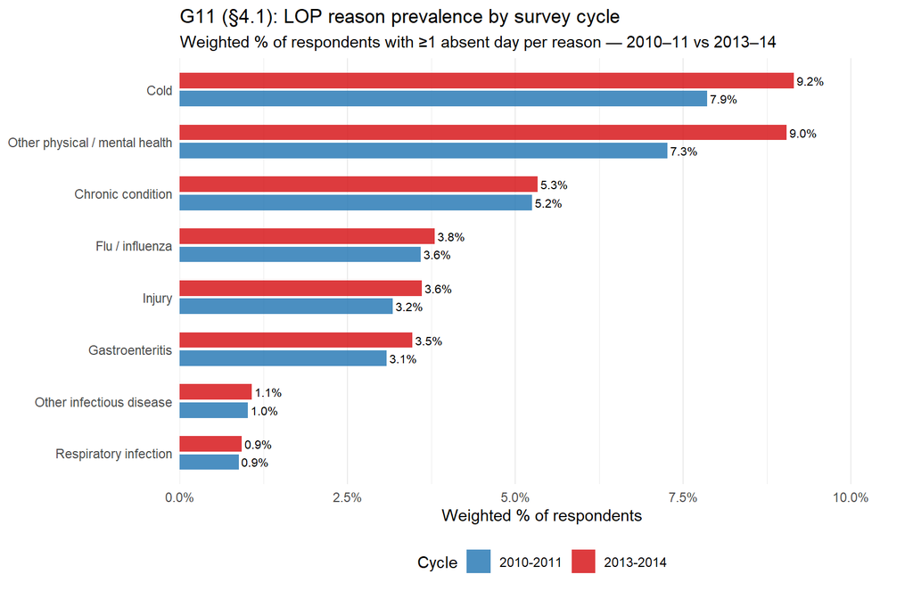

G11: Cycle comparison. Differences between the two waves may reflect question-wording refinements, seasonal variation, or true temporal shifts in population absenteeism patterns.

```r
# Faceted: prevalence by survey cycle

g1_data_by_cycle <- ds_lop_long %>%
  group_by(reason_label, cchs_cycle_f) %>%
  summarise(
    wt_positive  = sum(.data[[weight_col]][has_days], na.rm = TRUE),
    wt_total     = sum(.data[[weight_col]],           na.rm = TRUE),
    pct_weighted = wt_positive / wt_total * 100,
    .groups = "drop"
  ) %>%
  mutate(
    reason_label = forcats::fct_reorder(reason_label, pct_weighted,
                                         .fun = mean, .desc = FALSE)
  )

g11_lop_prevalence_by_cycle <- g1_data_by_cycle %>%
  ggplot(aes(x = pct_weighted, y = reason_label, fill = cchs_cycle_f)) +
  geom_col(position = position_dodge(width = 0.7), width = 0.6, alpha = 0.85) +
  geom_text(
    aes(label = sprintf("%.1f%%", pct_weighted)),
    position = position_dodge(width = 0.7),
    hjust    = -0.1,
    size     = 2.8
  ) +
  scale_x_continuous(
    labels = label_percent(scale = 1),
    expand = expansion(mult = c(0, 0.18))
  ) +
  scale_fill_manual(values = c("2010-2011" = "#2c7bb6", "2013-2014" = "#d7191c")) +
  labs(
    title    = "G11 (\u00a74.1): LOP reason prevalence by survey cycle",
    subtitle = "Weighted % of respondents with \u22651 absent day per reason \u2014 2010\u201311 vs 2013\u201314",
    x        = "Weighted % of respondents",
    y        = NULL,
    fill     = "Cycle"
  ) +
  theme_minimal(base_size = 11) +
  theme(
    panel.grid.major.y = element_blank(),
    legend.position    = "bottom"
  )

ggsave(paste0(prints_folder, "g11_lop_prevalence_by_cycle.png"),
       g11_lop_prevalence_by_cycle, width = 8.5, height = 5.5, dpi = 300)
print(g11_lop_prevalence_by_cycle)
```

**G11 — Prevalence by survey cycle (2010–2011 vs 2013–2014)**

```r
# =============================================================================
# G2 FAMILY — Component Contribution to the Total Outcome
# Framing question: How much does each LOP reason contribute to the
#   weighted mean of days_absent_total?
# g2  : dot-strip lollipop — absolute weighted mean + % share label
# g21 : stacked bar — relative share of each component in the component sum
# =============================================================================
```

## G2 — Component Contribution to the Total Outcome

**Framing question**: How much does each LOP reason contribute — in absolute days and relative share — to the weighted mean of `days_absent_total`?

**Weighted mean days per reason, relative % share**

```r
g2_data <- ds_lop_long %>%
  group_by(reason_label) %>%
  summarise(
    wt_mean_days = sum(.data[[weight_col]] * days_reason, na.rm = TRUE) /
      sum(.data[[weight_col]], na.rm = TRUE),
    .groups = "drop"
  ) %>%
  arrange(desc(wt_mean_days)) %>%
  mutate(
    reason_label = forcats::fct_reorder(reason_label, wt_mean_days),
    pct_of_total = wt_mean_days / sum(wt_mean_days) * 100
  )

# Overall weighted mean of days_absent_total (reference line)
total_wt_mean <- sum(ds0[[weight_col]] * ds0$days_absent_total, na.rm = TRUE) /
  sum(ds0[[weight_col]], na.rm = TRUE)
```

**G2 — Lollipop chart, absolute contribution and share label**

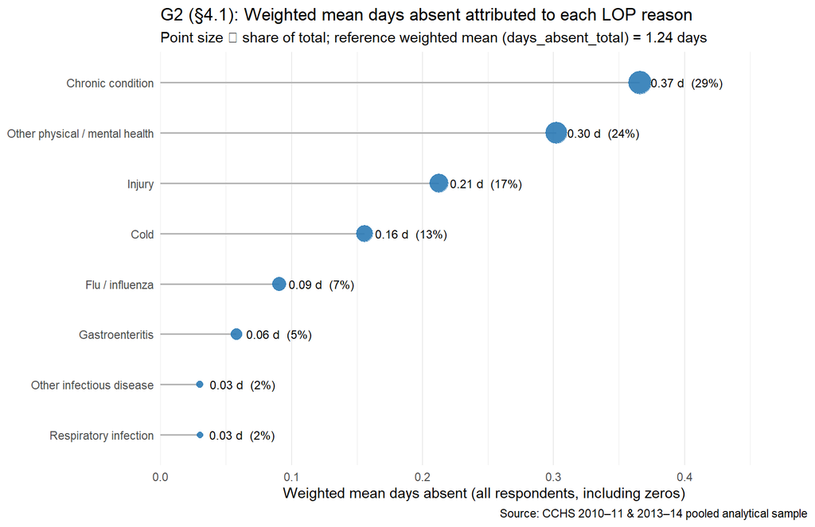

G2: Chronic condition typically contributes the largest absolute mean; the ‘other physical/mental health’ and injury components follow. Point size is proportional to the % share.

```r
g2_lop_contribution <- g2_data %>%
  ggplot(aes(x = wt_mean_days, y = reason_label)) +
  geom_segment(aes(xend = 0, yend = reason_label),
               colour = "grey70", linewidth = 0.6) +
  geom_point(aes(size = pct_of_total), colour = "#2c7bb6", alpha = 0.9) +
  geom_text(
    aes(label = sprintf("%.2f d  (%.0f%%)", wt_mean_days, pct_of_total)),
    hjust = -0.15,
    size  = 3.1
  ) +
  scale_x_continuous(expand = expansion(mult = c(0, 0.35))) +
  scale_size_continuous(range = c(2, 8), guide = "none") +
  labs(
    title    = "G2 (\u00a74.1): Weighted mean days absent attributed to each LOP reason",
    subtitle = sprintf(
      "Point size \u221d share of total; reference weighted mean (days_absent_total) = %.2f days",
      total_wt_mean
    ),
    x       = "Weighted mean days absent (all respondents, including zeros)",
    y       = NULL,
    caption = "Source: CCHS 2010\u201311 & 2013\u201314 pooled analytical sample"
  ) +
  theme_minimal(base_size = 11) +
  theme(panel.grid.major.y = element_blank())

ggsave(paste0(prints_folder, "g2_lop_contribution.png"),
       g2_lop_contribution, width = 8.5, height = 5.5, dpi = 300)
print(g2_lop_contribution)
```

**G21 — Horizontal stacked bar, relative shares of component sum**

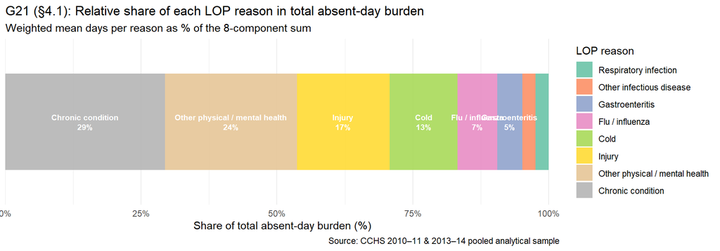

```r
# Stacked horizontal bar: relative share of each component in the total

# Preserve ordering from g2 (descending wt_mean)
g21_data <- g2_data %>%
  mutate(
    reason_ordered = forcats::fct_reorder(as.character(reason_label),
                                          pct_of_total, .desc = FALSE)
  )

g21_lop_contribution_stacked <- g21_data %>%
  ggplot(aes(x = pct_of_total, y = "Component sum", fill = reason_ordered)) +
  geom_col(width = 0.7, alpha = 0.88) +
  geom_text(
    data = filter(g21_data, pct_of_total > 4),
    aes(
      label = sprintf("%s\n%.0f%%", reason_ordered, pct_of_total)
    ),
    position   = position_stack(vjust = 0.5),
    size       = 2.8,
    colour     = "white",
    fontface   = "bold",
    lineheight = 1.0
  ) +
  scale_x_continuous(
    labels = label_percent(scale = 1),
    expand = expansion(mult = c(0, 0.02))
  ) +
  scale_fill_brewer(palette = "Set2", direction = 1) +
  labs(
    title    = "G21 (\u00a74.1): Relative share of each LOP reason in total absent-day burden",
    subtitle = "Weighted mean days per reason as % of the 8-component sum",
    x        = "Share of total absent-day burden (%)",
    y        = NULL,
    fill     = "LOP reason",
    caption  = "Source: CCHS 2010\u201311 & 2013\u201314 pooled analytical sample"
  ) +
  theme_minimal(base_size = 11) +
  theme(
    axis.text.y        = element_blank(),
    axis.ticks.y       = element_blank(),
    panel.grid.major.y = element_blank(),
    legend.position    = "right"
  )

ggsave(paste0(prints_folder, "g21_lop_contribution_stacked.png"),
       g21_lop_contribution_stacked, width = 10, height = 3.5, dpi = 300)
print(g21_lop_contribution_stacked)
```

**G21 — Horizontal stacked bar, relative shares of component sum**

```r
# =============================================================================
# G3 FAMILY — Co-occurrence of Reason Categories
# Framing question: How many reasons does a typical respondent report
#   simultaneously, and which reason pairs most frequently co-occur?
# g3  : bar chart — distribution of reason-count per respondent (0, 1, 2, …)
# g31 : tile heatmap — pairwise co-occurrence rates across 8 reason categories
# =============================================================================
```

## G3 — Co-occurrence of Reason Categories

**Framing question**: How many reason categories does a typical respondent report simultaneously, and which reason pairs most frequently co-occur?

**Per-respondent reason counts; pairwise co-occurrence matrix**

```r
# Per-respondent count of reason categories with ≥1 day
g3_count_data <- ds0 %>%
  select(cchs_cycle_f, !!weight_col, all_of(names(lop_components))) %>%
  mutate(
    n_reasons = rowSums(
      across(all_of(names(lop_components)), ~ !is.na(.x) & .x > 0),
      na.rm = TRUE
    )
  )

g3_dist <- g3_count_data %>%
  group_by(n_reasons) %>%
  summarise(
    n_obs = n(),
    wt_n  = sum(.data[[weight_col]], na.rm = TRUE),
    .groups = "drop"
  ) %>%
  mutate(
    pct_obs = n_obs / sum(n_obs) * 100,
    pct_wt  = wt_n  / sum(wt_n)  * 100
  )

# Pairwise co-occurrence matrix (% of respondents positive on both)
lop_cols   <- names(lop_components)
lop_labels <- unname(lop_components)

positive_flags <- ds0 %>%
  select(all_of(lop_cols)) %>%
  mutate(across(everything(), ~ !is.na(.x) & .x > 0))

cooccur_mat <- matrix(
  NA_real_,
  nrow     = length(lop_cols),
  ncol     = length(lop_cols),
  dimnames = list(lop_labels, lop_labels)
)

for (i in seq_along(lop_cols)) {
  for (j in seq_along(lop_cols)) {
    cooccur_mat[i, j] <- mean(
      positive_flags[[lop_cols[i]]] & positive_flags[[lop_cols[j]]],
      na.rm = TRUE
    ) * 100
  }
}

g3_cooccur_data <- as.data.frame(cooccur_mat) %>%
  tibble::rownames_to_column("reason_row") %>%
  tidyr::pivot_longer(-reason_row, names_to = "reason_col",
                      values_to = "pct_cooccur") %>%
  mutate(
    reason_row = factor(reason_row, levels = rev(lop_labels)),
    reason_col = factor(reason_col, levels = lop_labels),
    is_diagonal = reason_row == reason_col
  )
```

**G3 — Bar chart, number of reason categories per respondent**

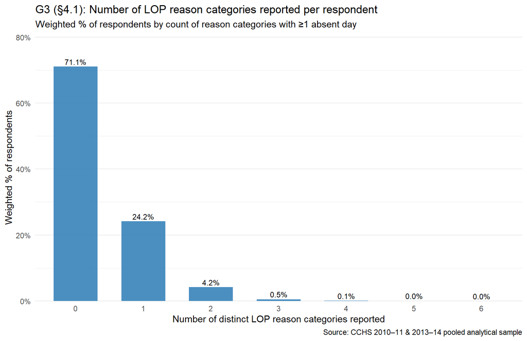

G3: The large majority of respondents with any absence report exactly 1 reason category. The existence of multi-reason reporters informs interpretation: the additive construction of days_absent_total is valid but may mask distinct absence episodes.

```r
g3_lop_nreasons <- g3_dist %>%
  ggplot(aes(x = factor(n_reasons), y = pct_wt)) +
  geom_col(fill = "#2c7bb6", alpha = 0.85, width = 0.65) +
  geom_text(
    aes(label = sprintf("%.1f%%", pct_wt)),
    vjust = -0.35,
    size  = 3.2
  ) +
  scale_y_continuous(
    labels = label_percent(scale = 1),
    expand = expansion(mult = c(0, 0.14))
  ) +
  labs(
    title    = "G3 (\u00a74.1): Number of LOP reason categories reported per respondent",
    subtitle = "Weighted % of respondents by count of reason categories with \u22651 absent day",
    x        = "Number of distinct LOP reason categories reported",
    y        = "Weighted % of respondents",
    caption  = "Source: CCHS 2010\u201311 & 2013\u201314 pooled analytical sample"
  ) +
  theme_minimal(base_size = 11) +
  theme(panel.grid.major.x = element_blank())

ggsave(paste0(prints_folder, "g3_lop_nreasons.png"),
       g3_lop_nreasons, width = 8.5, height = 5.5, dpi = 300)
print(g3_lop_nreasons)
```

**G31 — Pairwise co-occurrence tile heatmap**

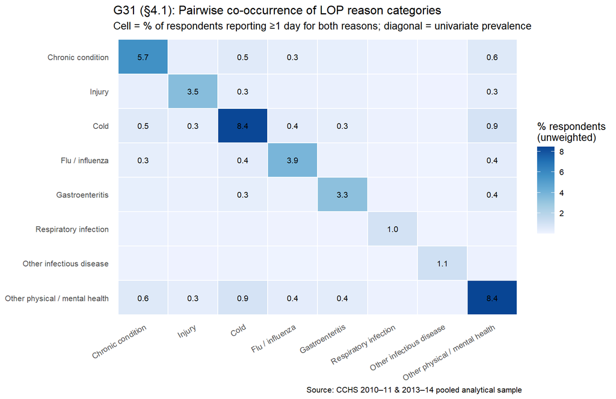

```r
# Pairwise co-occurrence heatmap; diagonal = univariate prevalence

g31_lop_cooccurrence <- g3_cooccur_data %>%
  ggplot(aes(x = reason_col, y = reason_row, fill = pct_cooccur)) +
  geom_tile(colour = "white", linewidth = 0.5) +
  geom_text(
    aes(label = ifelse(pct_cooccur >= 0.3, sprintf("%.1f", pct_cooccur), "")),
    size = 2.8
  ) +
  scale_fill_distiller(
    palette   = "Blues",
    direction = 1,
    name      = "% respondents\n(unweighted)"
  ) +
  labs(
    title    = "G31 (\u00a74.1): Pairwise co-occurrence of LOP reason categories",
    subtitle = "Cell = % of respondents reporting \u22651 day for both reasons; diagonal = univariate prevalence",
    x        = NULL,
    y        = NULL,
    caption  = "Source: CCHS 2010\u201311 & 2013\u201314 pooled analytical sample"
  ) +
  theme_minimal(base_size = 10) +
  theme(
    axis.text.x = element_text(angle = 30, hjust = 1),
    panel.grid  = element_blank()
  )

ggsave(paste0(prints_folder, "g31_lop_cooccurrence.png"),
       g31_lop_cooccurrence, width = 8.5, height = 5.5, dpi = 300)
print(g31_lop_cooccurrence)
```

**G31 — Pairwise co-occurrence tile heatmap**

```r
# =============================================================================
# G4 FAMILY — Conditional Intensity: Days Produced Per Reason, Among Reporters
# Framing question: Among workers who missed work for a given reason,
#   how many days did that reason typically produce?
# g4  : horizontal bar (weighted mean) + diamond (median) per reason, reporters only
# g41 : distribution of days_absent_total (non-zeros, log y-scale)
# =============================================================================
```

## G4 — Conditional Intensity Among Reporters

**Framing question**: Among workers who missed ≥1 day *for a specific reason*, how many days did that reason typically produce?

**Weighted mean and median days per reason, reporters only**

```r
# Restrict to respondents who reported ≥1 day for each specific reason
g4_data <- ds_lop_long %>%
  filter(has_days) %>%
  group_by(reason_label) %>%
  summarise(
    wt_mean_days = sum(.data[[weight_col]] * days_reason, na.rm = TRUE) /
      sum(.data[[weight_col]], na.rm = TRUE),
    mean_days    = mean(days_reason, na.rm = TRUE),
    median_days  = median(days_reason, na.rm = TRUE),
    n_reporters  = n(),
    .groups = "drop"
  ) %>%
  mutate(reason_label = forcats::fct_reorder(reason_label, wt_mean_days))

n_zero_total <- sum(ds0$days_absent_total == 0, na.rm = TRUE)
pct_zero_total <- n_zero_total / nrow(ds0) * 100

g41_data <- ds0 %>%
  filter(!is.na(days_absent_total), days_absent_total >= 1) %>%
  count(days_absent_total, name = "n_respondents")
```

**G4 — Bar (weighted mean) + diamond (median), reporters only**

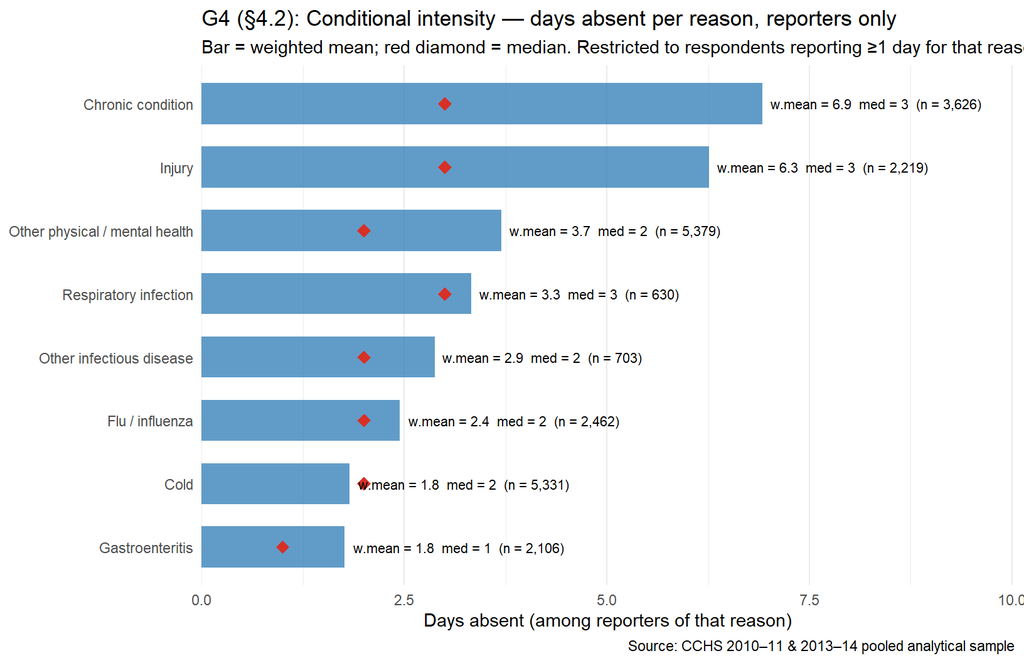

```r
g4_conditional_intensity <- g4_data %>%
  ggplot(aes(x = wt_mean_days, y = reason_label)) +
  geom_col(fill = "#2c7bb6", alpha = 0.75, width = 0.65) +
  geom_point(aes(x = median_days), colour = "#d73027", size = 3.5, shape = 18) +
  geom_text(
    aes(
      label = sprintf("w.mean = %.1f  med = %.0f  (n = %s)",
                      wt_mean_days, median_days,
                      scales::comma(n_reporters))
    ),
    hjust = -0.04,
    size  = 2.9
  ) +
  scale_x_continuous(expand = expansion(mult = c(0, 0.45))) +
  labs(
    title    = "G4 (\u00a74.2): Conditional intensity \u2014 days absent per reason, reporters only",
    subtitle = "Bar = weighted mean; red diamond = median. Restricted to respondents reporting \u22651 day for that reason.",
    x        = "Days absent (among reporters of that reason)",
    y        = NULL,
    caption  = "Source: CCHS 2010\u201311 & 2013\u201314 pooled analytical sample"
  ) +
  theme_minimal(base_size = 11) +
  theme(panel.grid.major.y = element_blank())

ggsave(paste0(prints_folder, "g4_conditional_intensity.png"),
       g4_conditional_intensity, width = 8.5, height = 5.5, dpi = 300)
print(g4_conditional_intensity)
```

**G41 — Distribution of days_absent_total (non-zeros, log y)**

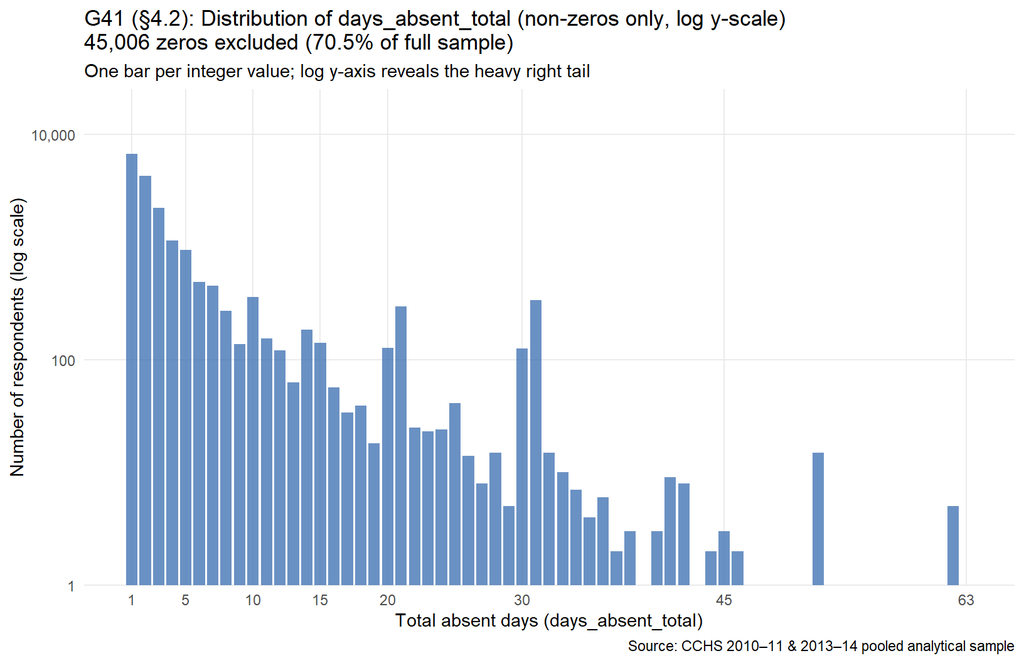

G41: Log y-scale reveals the full extent of the right tail. The vast majority of absent workers cluster at 1–5 days; the tail extends to 63 days (the empirical cap in this sample).

```r
# Distribution of days_absent_total: non-zeros, log y-scale

g41_total_distribution <- g41_data %>%
  ggplot(aes(x = days_absent_total, y = n_respondents)) +
  geom_col(fill = "#4575b4", alpha = 0.80, width = 0.85) +
  scale_y_log10(
    labels = label_comma(),
    expand = expansion(mult = c(0, 0.15))
  ) +
  scale_x_continuous(breaks = c(1, 5, 10, 15, 20, 30, 45, 63)) +
  labs(
    title    = sprintf(
      "G41 (\u00a74.2): Distribution of days_absent_total (non-zeros only, log y-scale)\n%s zeros excluded (%.1f%% of full sample)",
      scales::comma(n_zero_total), pct_zero_total
    ),
    subtitle = "One bar per integer value; log y-axis reveals the heavy right tail",
    x        = "Total absent days (days_absent_total)",
    y        = "Number of respondents (log scale)",
    caption  = "Source: CCHS 2010\u201311 & 2013\u201314 pooled analytical sample"
  ) +
  theme_minimal(base_size = 11) +
  theme(panel.grid.minor = element_blank())

ggsave(paste0(prints_folder, "g41_total_distribution.png"),
       g41_total_distribution, width = 8.5, height = 5.5, dpi = 300)
print(g41_total_distribution)
```

**G41 — Distribution of days_absent_total (non-zeros, log y)**

```r
# =============================================================================
# G5 FAMILY — Chronic Condition's Structural Role Among Absent Workers
# Framing question: Among workers who missed at least one day, how central
#   is the chronic-condition component to the total?
# g5  : three-group bar — no chronic / mixed / entirely chronic
# g51 : bubble chart — days_absent_chronic vs days_absent_total (both > 0)
# =============================================================================
```

## G5 — Chronic Condition’s Structural Role

**Framing question**: Among workers who missed at least one day, how central is the chronic-condition component? Are most absent workers absent *only* for chronic reasons, or is the absence mixed?

**Three-group classification; bubble-chart data**

```r
g5_data <- ds0 %>%
  filter(!is.na(days_absent_total), days_absent_total > 0) %>%
  mutate(
    chr   = ifelse(is.na(days_absent_chronic), 0L, days_absent_chronic),
    group = dplyr::case_when(
      chr == 0                 ~ "No chronic days\n(non-chronic absence only)",
      chr == days_absent_total ~ "Entirely chronic\n(chronic = total)",
      TRUE                     ~ "Mixed\n(some chronic + other reasons)"
    ),
    group = factor(group, levels = c(
      "No chronic days\n(non-chronic absence only)",
      "Mixed\n(some chronic + other reasons)",
      "Entirely chronic\n(chronic = total)"
    ))
  ) %>%
  group_by(group) %>%
  summarise(
    n        = n(),
    wt_n     = sum(.data[[weight_col]], na.rm = TRUE),
    .groups  = "drop"
  ) %>%
  mutate(
    pct_n  = n    / sum(n)    * 100,
    pct_wt = wt_n / sum(wt_n) * 100
  )

n_absent_total <- sum(g5_data$n)

g51_data <- ds0 %>%
  filter(
    !is.na(days_absent_total),    days_absent_total > 0,
    !is.na(days_absent_chronic),  days_absent_chronic > 0
  ) %>%
  count(days_absent_total, days_absent_chronic, name = "n_combo")
```

**G5 — Three-group bar (no chronic / mixed / entirely chronic)**

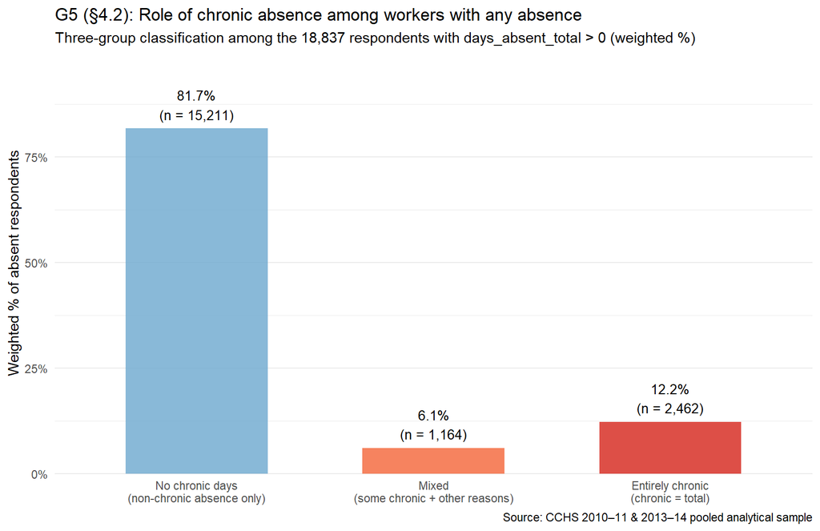

G5: Among absent workers, the largest group has no chronic-condition days — their absence is driven entirely by acute or other reasons. A meaningful minority report purely chronic absence. The mixed group captures those for whom chronic conditions are one of several concurrent reasons.

```r
g5_chronic_role <- g5_data %>%
  ggplot(aes(x = group, y = pct_wt, fill = group)) +
  geom_col(width = 0.6, alpha = 0.85) +
  geom_text(
    aes(label = sprintf("%.1f%%\n(n = %s)", pct_wt, scales::comma(n))),
    vjust = -0.3,
    size  = 3.5
  ) +
  scale_y_continuous(
    labels = label_percent(scale = 1),
    expand = expansion(mult = c(0, 0.22))
  ) +
  scale_fill_manual(
    values = c(
      "No chronic days\n(non-chronic absence only)" = "#74add1",
      "Mixed\n(some chronic + other reasons)"        = "#f46d43",
      "Entirely chronic\n(chronic = total)"          = "#d73027"
    ),
    guide = "none"
  ) +
  labs(
    title    = "G5 (\u00a74.2): Role of chronic absence among workers with any absence",
    subtitle = sprintf(
      "Three-group classification among the %s respondents with days_absent_total > 0 (weighted %%)",
      scales::comma(n_absent_total)
    ),
    x        = NULL,
    y        = "Weighted % of absent respondents",
    caption  = "Source: CCHS 2010\u201311 & 2013\u201314 pooled analytical sample"
  ) +
  theme_minimal(base_size = 11) +
  theme(panel.grid.major.x = element_blank())

ggsave(paste0(prints_folder, "g5_chronic_role.png"),
       g5_chronic_role, width = 8.5, height = 5.5, dpi = 300)
print(g5_chronic_role)
```

**G51 — Bubble chart, chronic days vs total days (both > 0)**

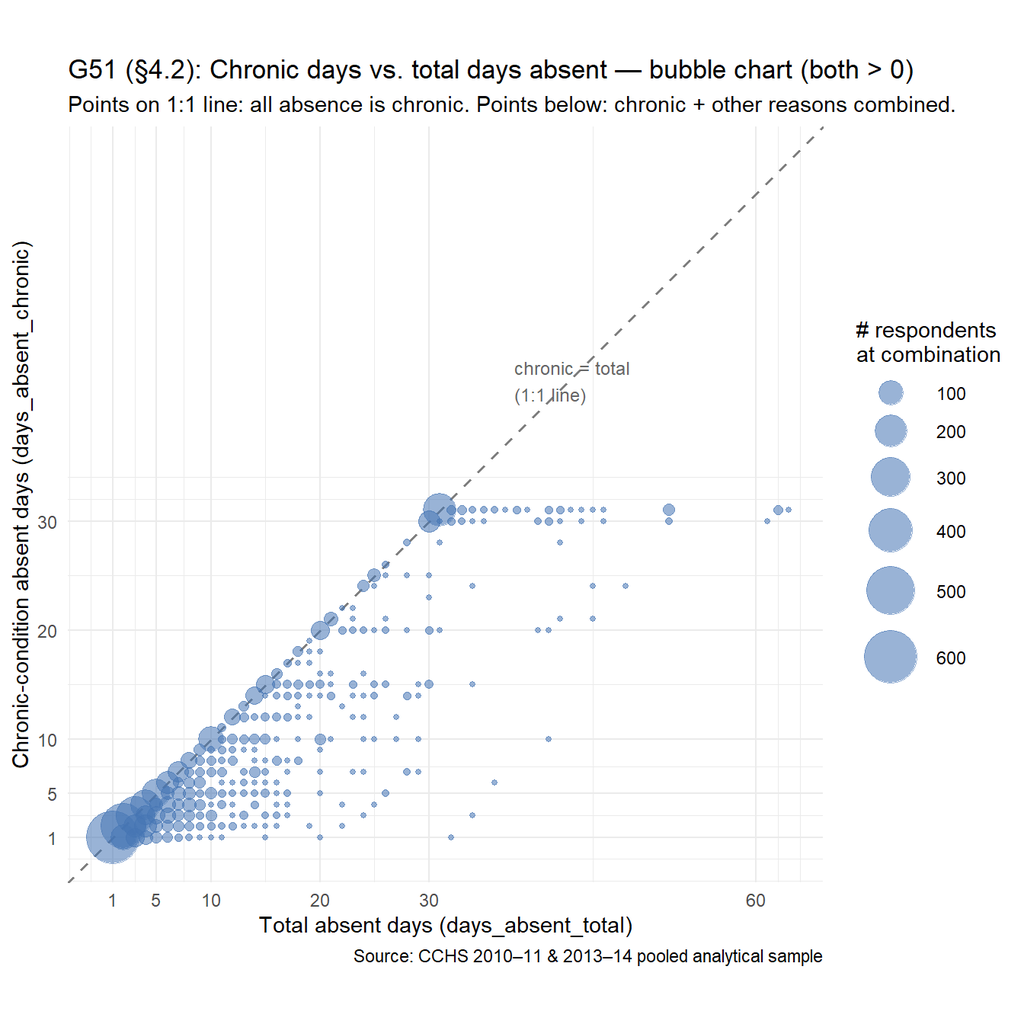

G51: Points on the 1:1 dashed line indicate that all absence is attributable to chronic conditions. Points below the line represent respondents with additional non-chronic days. The concentration near the 1:1 line among longer-absence cases is consistent with chronic conditions driving sustained absence.

```r
# Bubble chart: chronic days vs total days, 1:1 reference line

g51_max_axis <- max(g51_data$days_absent_total, g51_data$days_absent_chronic)

g51_chronic_vs_total <- g51_data %>%
  ggplot(aes(x = days_absent_total, y = days_absent_chronic, size = n_combo)) +
  geom_abline(slope = 1, intercept = 0, colour = "grey50", linetype = "dashed",
              linewidth = 0.7) +
  geom_point(alpha = 0.55, colour = "#4575b4") +
  scale_size_continuous(
    name   = "# respondents\nat combination",
    range  = c(1, 12),
    labels = label_comma()
  ) +
  scale_x_continuous(breaks = c(1, 5, 10, 20, 30, 60)) +
  scale_y_continuous(breaks = c(1, 5, 10, 20, 30)) +
  coord_fixed(
    xlim = c(0, g51_max_axis),
    ylim = c(0, g51_max_axis)
  ) +
  annotate(
    "text",
    x      = g51_max_axis * 0.60,
    y      = g51_max_axis * 0.68,
    label  = "chronic = total\n(1:1 line)",
    colour = "grey40",
    size   = 3.2,
    hjust  = 0
  ) +
  labs(
    title    = "G51 (\u00a74.2): Chronic days vs. total days absent \u2014 bubble chart (both > 0)",
    subtitle = "Points on 1:1 line: all absence is chronic. Points below: chronic + other reasons combined.",
    x        = "Total absent days (days_absent_total)",
    y        = "Chronic-condition absent days (days_absent_chronic)",
    caption  = "Source: CCHS 2010\u201311 & 2013\u201314 pooled analytical sample"
  ) +
  theme_minimal(base_size = 11)

ggsave(paste0(prints_folder, "g51_chronic_vs_total.png"),
       g51_chronic_vs_total, width = 7.0, height = 7.0, dpi = 300)
print(g51_chronic_vs_total)
```

**G51 — Bubble chart, chronic days vs total days (both > 0)**

```r
# =============================================================================
# G6 FAMILY — LOP Component Availability (Data Quality Validation)
# Framing question: Are all 8 LOP components complete in the analytical
#   sample, confirming that zeros are preserved and element-wise exclusion
#   upstream eliminated only rows with genuine missingness?
# g6  : 100% stacked bar — zero vs positive per component
# g61 : lollipop — weighted mean raw days per component (population average)
# =============================================================================
```

## G6 — LOP Component Availability (Data Quality Validation)

**Framing question**: Are all 8 LOP components complete in the analytical sample, confirming that zeros are preserved as valid responses and that the element-wise exclusion upstream resolved all missingness?

> **Context (Marc-André, 2026-05-15)**: A concern was raised that element-wise exclusion — dropping a respondent if *any* LOP component is missing — could unnecessarily reduce the sample if missingness is rare and non-systematic. The CACHE manifest confirms that 405 respondents were excluded at Ellis step 4 (out of 64,248 employed respondents: a ~0.6% loss). G6 validates that the 63,843 retained rows have *no* missing values on any LOP component, and that zero is correctly encoded as an integer rather than `NA`.

**Per-component status: zero vs positive vs missing**

```r
# Per-component: count of zeros, positives, and missing (should be 0 after exclusion)

g6_long <- ds0 %>%
  select(all_of(names(lop_components)), !!weight_col) %>%
  tidyr::pivot_longer(
    cols      = all_of(names(lop_components)),
    names_to  = "lop_col",
    values_to = "days"
  ) %>%
  mutate(
    reason_label = factor(lop_components[lop_col], levels = lop_components),
    status = dplyr::case_when(
      is.na(days) ~ "Missing (NA)",
      days == 0   ~ "Zero days",
      TRUE        ~ "\u22651 day absent"
    ),
    status = factor(status, levels = c("\u22651 day absent", "Zero days", "Missing (NA)"))
  )

g6_data <- g6_long %>%
  group_by(reason_label, status) %>%
  summarise(
    n    = n(),
    wt_n = sum(.data[[weight_col]], na.rm = TRUE),
    .groups = "drop"
  ) %>%
  group_by(reason_label) %>%
  mutate(
    pct_n  = n    / sum(n)    * 100,
    pct_wt = wt_n / sum(wt_n) * 100
  ) %>%
  ungroup() %>%
  # Order reasons by descending % positive
  mutate(
    reason_label = forcats::fct_reorder(
      reason_label,
      ifelse(status == "\u22651 day absent", pct_n, NA_real_),
      .fun  = function(x) max(x, na.rm = TRUE),
      .desc = FALSE
    )
  )

# Weighted mean raw days per component (across all respondents, including zeros)
g61_data <- ds_lop_long %>%
  group_by(reason_label) %>%
  summarise(
    wt_mean_raw = sum(.data[[weight_col]] * days_reason, na.rm = TRUE) /
      sum(.data[[weight_col]], na.rm = TRUE),
    .groups = "drop"
  ) %>%
  mutate(reason_label = forcats::fct_reorder(reason_label, wt_mean_raw))
```

**G6 — 100% stacked bar, component availability**

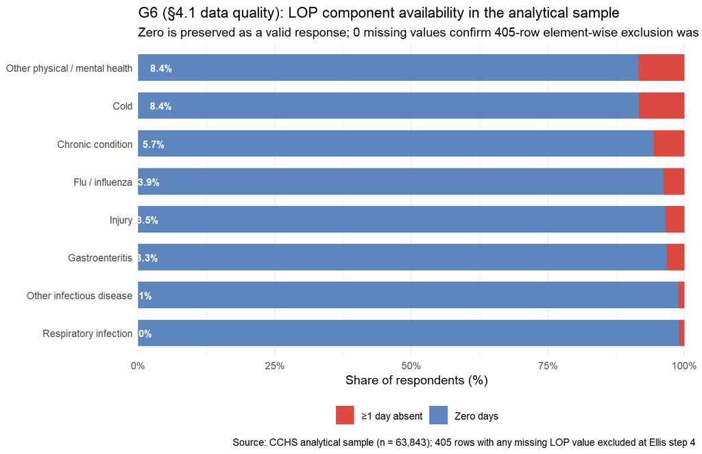

G6: All 8 LOP components have zero missing values in the analytical sample — the grey ‘Missing’ segment is absent from every bar. The blue ‘zero days’ majority share is a substantive finding (most respondents did not miss work for that reason), not a data artefact.

```r
g6_lop_availability <- g6_data %>%
  ggplot(aes(x = pct_n, y = reason_label, fill = status)) +
  geom_col(width = 0.70, alpha = 0.88) +
  geom_text(
    data = filter(g6_data, status == "\u22651 day absent"),
    aes(label = sprintf("%.1f%%", pct_n), x = pct_n / 2),
    colour   = "white",
    fontface = "bold",
    size     = 3.2
  ) +
  scale_x_continuous(
    labels = scales::label_percent(scale = 1),
    expand = expansion(mult = c(0, 0.02))
  ) +
  scale_fill_manual(
    values = c(
      "\u22651 day absent" = "#d73027",
      "Zero days"          = "#4575b4",
      "Missing (NA)"       = "#969696"
    )
  ) +
  labs(
    title    = "G6 (\u00a74.1 data quality): LOP component availability in the analytical sample",
    subtitle = "Zero is preserved as a valid response; 0 missing values confirm 405-row element-wise exclusion was resolved upstream",
    x        = "Share of respondents (%)",
    y        = NULL,
    fill     = NULL,
    caption  = "Source: CCHS analytical sample (n = 63,843); 405 rows with any missing LOP value excluded at Ellis step 4"
  ) +
  theme_minimal(base_size = 11) +
  theme(
    panel.grid.major.y = element_blank(),
    legend.position    = "bottom"
  )

ggsave(paste0(prints_folder, "g6_lop_availability.png"),
       g6_lop_availability, width = 8.5, height = 5.5, dpi = 300)
print(g6_lop_availability)
```

**G61 — Weighted mean raw days per component (population average)**

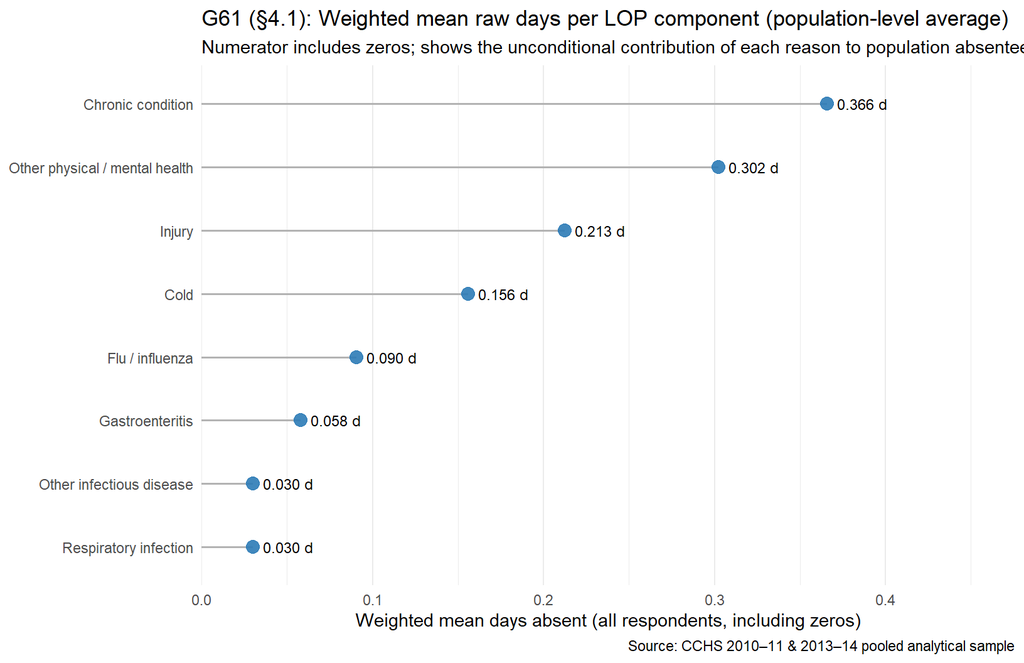

G61: The population-level (unconditional) mean days per component includes zeros in the denominator. Chronic condition consistently produces the highest mean despite having the zeros counted — the contrast with conditional G4 magnitudes reveals how skewed the reporter subgroup is.

```r
# Lollipop: weighted mean raw days per LOP component (population average)

g61_lop_mean_raw <- g61_data %>%
  ggplot(aes(x = wt_mean_raw, y = reason_label)) +
  geom_segment(aes(xend = 0, yend = reason_label),
               colour = "grey70", linewidth = 0.6) +
  geom_point(colour = "#2c7bb6", size = 3.5, alpha = 0.9) +
  geom_text(
    aes(label = sprintf("%.3f d", wt_mean_raw)),
    hjust = -0.2,
    size  = 3.1
  ) +
  scale_x_continuous(expand = expansion(mult = c(0, 0.30))) +
  labs(
    title    = "G61 (\u00a74.1): Weighted mean raw days per LOP component (population-level average)",
    subtitle = "Numerator includes zeros; shows the unconditional contribution of each reason to population absenteeism",
    x        = "Weighted mean days absent (all respondents, including zeros)",
    y        = NULL,
    caption  = "Source: CCHS 2010\u201311 & 2013\u201314 pooled analytical sample"
  ) +
  theme_minimal(base_size = 11) +
  theme(panel.grid.major.y = element_blank())

ggsave(paste0(prints_folder, "g61_lop_mean_raw.png"),
       g61_lop_mean_raw, width = 8.5, height = 5.5, dpi = 300)
print(g61_lop_mean_raw)
```

**G62 — LOP component reporting rate with completeness colour scale**

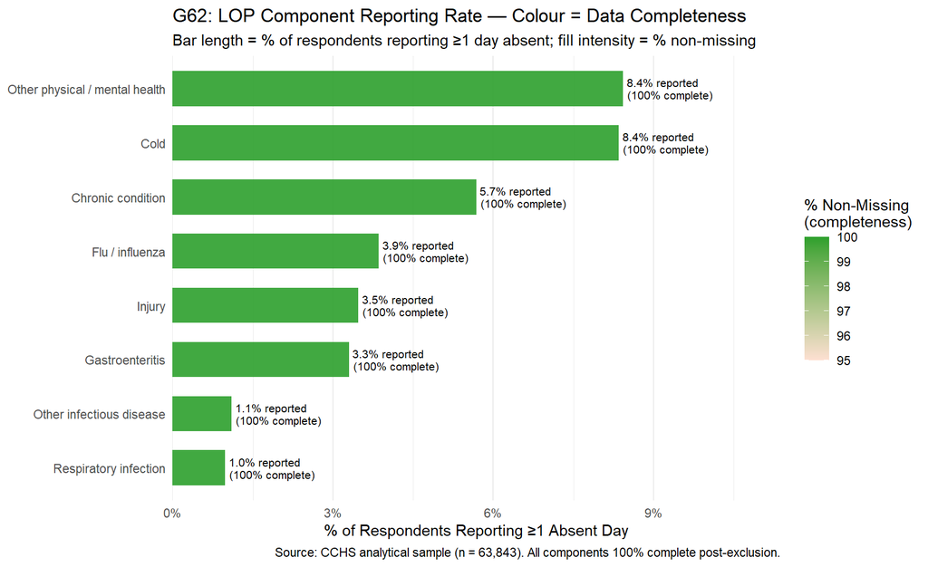

G62: Bar length shows the reporting rate (% with ≥1 absent day); fill colour maps to data completeness (% non-missing). All 8 components are 100% complete in the post-exclusion analytical sample.

```r
# Per-component: percent of respondents with a non-missing, non-zero response
# Color-mapped to % non-missing (completeness gradient) per Marc-André feedback
# (2026-05-15: "colors should probably be remapped to percent non-missing")

g62_data <- g6_long %>%
  group_by(reason_label) %>%
  summarise(
    n_total      = n(),
    n_missing    = sum(status == "Missing (NA)"),
    n_nonmissing = n_total - n_missing,
    pct_complete = n_nonmissing / n_total * 100,
    n_positive   = sum(status == "\u22651 day absent"),
    pct_positive = n_positive / n_total * 100,
    .groups = "drop"
  ) %>%
  mutate(reason_label = forcats::fct_reorder(reason_label, pct_positive))

g62_completeness <- g62_data %>%
  ggplot(aes(x = pct_positive, y = reason_label, fill = pct_complete)) +
  geom_col(width = 0.65, alpha = 0.9) +
  geom_text(aes(label = sprintf("%.1f%% reported\n(%.0f%% complete)",
                                pct_positive, pct_complete)),
            hjust = -0.05, size = 2.8, lineheight = 0.9) +
  scale_x_continuous(
    expand = expansion(mult = c(0, 0.35)),
    labels = scales::label_percent(scale = 1)
  ) +
  scale_fill_gradient(
    low  = "#fee0d2",
    high = "#2ca02c",
    name = "% Non-Missing\n(completeness)",
    limits = c(95, 100)
  ) +
  labs(
    title    = "G62: LOP Component Reporting Rate — Colour = Data Completeness",
    subtitle = "Bar length = % of respondents reporting \u22651 day absent; fill intensity = % non-missing",
    x        = "% of Respondents Reporting \u22651 Absent Day",
    y        = NULL,
    caption  = "Source: CCHS analytical sample (n = 63,843). All components 100% complete post-exclusion."
  ) +
  theme_minimal(base_size = 11) +
  theme(
    panel.grid.major.y = element_blank(),
    legend.position    = "right"
  )
print(g62_completeness)
```

**G62 — LOP component reporting rate with completeness colour scale**

```r
ggsave(paste0(prints_folder, "g62_completeness.png"),
       g62_completeness, width = 9, height = 5.5, dpi = 300)

# nolint end
```

# Session Info

**Reproducibility record**

```r
cat("Rendered:", format(Sys.time(), "%Y-%m-%d %H:%M:%S"), "\n")
```

```
Rendered: 2026-05-23 06:56:31
```